# Aula 4 - Econometria de Séries Temporais

João Ricardo F. de Lima

06 de Agosto de 2023.

# 1 Modelos Básicos de Séries Temporais

## 1.1 Ruído Branco

Uma série $Y_t$ é um ruído branco se

$$Y_t=\epsilon_t \qquad e \qquad \epsilon_t \thicksim
iid(0,\sigma^2_\epsilon)$$

ou seja, $Y_t$ é igual a uma variável aleatória $\epsilon_t$ independente (não autocorrelacionada) e igualmente distribuída (em todo o período de tempo t) com média zero e variância constante;

## 1.2 Passeio Aleatório

Uma série $Y_t$ é um Passeio Aleatório se

$$Y_t=Y_{t-1}+\epsilon_t$$

e um Passeio Aleatório com Constante (drift) se

$$Y_t=\alpha+Y_{t-1}+\epsilon_t$$

No caso do passeio aleatório puro, observar que a sua primeira diferença é um ruído branco.

$$Y_t=Y_{t-1}+\epsilon_t$$

$$Y_t-Y_{t-1}=\Delta Y_t=\epsilon_t$$

## 1.3 Modelos Autorregressivos (AR)

Os **modelos autorregressivos** (AR) sao definidos pela série em função de seus valores defasados mais um erro aleatório ruído branco. O número de variáveis defasadas define a “ordem” do modelo.

$$AR(1): Y_t=\phi_0+\phi_1Y_{t-1}+\epsilon_t$$

$$AR(2): Y_t=\phi_0+\phi_1Y_{t-1}+\phi_2Y_{t-2}+\epsilon_t$$

$$AR(3): Y_t=\phi_0+\phi_1Y_{t-1}+\phi_2Y_{t-2}+\phi_3Y_{t-3}+\epsilon_t$$

Generalizando:

$$AR(p): Y_t=\phi_0+\phi_1Y_{t-1}+\phi_2Y_{t-2}+\phi_3Y_{t-3}+ \dots
+\phi_pY_{t-p}+\epsilon_t$$

Usando o operador de defasagem o modelo autorregressivo pode ser reescrito como:

$$Y_t=\phi_0+\phi_1LY_t+\phi_2L^2Y_t+\phi_3L^3Y_t+ \dots
+\phi_pL^pY_{t}+\epsilon_t$$
$$(1-\phi_1L-\phi_2L^2-\phi_3L^3- \dots -\phi_pL^p)Y_t=\phi_0+\epsilon_t$$

ou ainda como

$$\phi(L)Y_t=\phi_0+\epsilon_t$$

## 1.4 Modelos Médias Móveis (MA)

Nos **modelos de médias móveis** (MA) a série $Y_t$ é definida como uma média ponderada de erros (choques) correntes e passados ocorridos em relação ao nível médio da série. O número de termos defasados define a ordem do modelo.

$$MA(1): Y_t=\mu+\epsilon_t+\theta_1\epsilon_{t-1}$$
$$MA(2): Y_t=\mu+\epsilon_t+\theta_1\epsilon_{t-1}+\theta_2\epsilon_{t-2}$$

$$MA(3):
Y_t=\mu+\epsilon_t+\theta_1\epsilon_{t-1}+\theta_2\epsilon_{t-2}+\theta_3\epsilon_{t-3}$$

Generalizando:

$$MA(q):
Y_t=\mu+\epsilon_t+\theta_1\epsilon_{t-1}+\theta_2\epsilon_{t-2}+\theta_3\epsilon_{t-3}+\dots+\theta_q\epsilon_{t-q}$$

Usando o operador de defasagem o modelo de médias móveis pode ser reescrito como:

$$Y_t=\mu+\epsilon_t+\theta_1L\epsilon_t+\theta_2L^2\epsilon_t+\theta_3L^3\epsilon_t+\dots+\theta_qL^q\epsilon_t$$

$$Y_t=\mu+(1+\theta_1L+\theta_2L^2+\theta_3L^3+\dots+\theta_qL^q)\epsilon_t$$

ou ainda como

$$Y_t=\mu+\theta(L)\epsilon_t$$

## 1.5 Modelos Autorregressivos e de Médias Móveis (ARMA)

os **modelos autorregressivos e de médias móveis** (ARMA) são formados por combinações de AR e MA.

$$ARMA(1,1): Y_t=\phi_0+\phi_1Y_{t-1}+\epsilon_t+\theta_1\epsilon_{t-1}$$

$$ARMA(2,1):
Y_t=\phi_0+\phi_1Y_{t-1}+\phi_2Y_{t-2}+\epsilon_t+\theta_1\epsilon_{t-1}$$

$$ARMA(2,2):
Y_t=\phi_0+\phi_1Y_{t-1}+\phi_2Y_{t-2}+\epsilon_t+\theta_1\epsilon_{t-1}+\theta_2\epsilon_{t-2}$$

Generalizando, ARMA(p,q):

$$Y_t=\phi_0+\phi_1Y_{t-1}+\phi_2Y_{t-2}+\phi_3Y_{t-3}+ \dots
+\phi_pY_{t-p}+
\epsilon_t+\theta_1\epsilon_{t-1}+\theta_2\epsilon_{t-2}+\theta_3\epsilon_{t-3}+\dots+\theta_q\epsilon_{t-q}$$

Com o uso do operador de defasagem, compactamente tem-se

$$\phi(L)Y_t=\phi_0+\theta(L)\epsilon_t$$

## 1.6 Modelos Autorregressivos Integrados de Médias Móveis (ARIMA)

os modelos AR(p), MA(q) e ARMA(p,q) não são adequados se as séries não forem estacionárias e precisarem ser diferenciadas. Séries como o Passeio Aleatório que precisam ser diferenciadas “d” vezes para se tornarem estacionárias são chamadas de *séries integradas de ordem d*;

Uma série não estacionária $Y_t$ integrada de ordem d, ou seja, $Y_t \thicksim I(d)$, segue um modelo autoregressivo integrado de médias móveis de ordem (p,d,q), conhecido como ARIMA (p,d,q) se

$$\Delta^dY_t=(1-L)^dY_t=\phi_1Y_{t-1}+\phi_2Y_{t-2}+\dots +\phi_pY_{t-p}+
\epsilon_t+\theta_1\epsilon_{t-1}+\theta_2\epsilon_{t-2}+\dots+\theta_q\epsilon_{t-q}$$

ou ainda como

$$\phi(L)\Delta^dY_t=\theta(L)\epsilon_t$$

# 2 Estacionariedade

Um processo estocástico é dito estacionário quando suas características probabilísticas não mudam ao longo do tempo.

Duas formas de estacionariedade: **Forte**, quando as funções de distribuição de probabilidades conjuntas são iguais ao longo do tempo e **Fraca**, quando dado uma série temporal $Y_t$, a média é constante ($E(Y_t)=\mu$), a variância é constante ($Var(Y_t)=\sigma^2$) e a covariância depende apenas do lag $k$ (defasagem) ($cov(Y_t,Y_{t-1})=f(k)$)

## 2.1 FAC e FACp

No máximo, o gráfico de uma série sugere se a mesma é ou não estacionária. Nos anos 70, Box e Jenkins utilizavam da análise de “correlogramas” para identificar se uma série era I(0) ou não.

Correlogramas são gráficos da função de autocorrelação (FAC) e de autocorrelação parcial (FACp), assim definidos:

$$FAC=\rho_k=\frac{cov(Y_t,Y_{t-k})}{\sqrt{var(Y_t)var(Y_{t-k})}}$$

sendo que a FAC varia de +1 a -1.

Ou, considerando que a série é estacionária, as variâncias são iguais

$$\rho_k=\frac{cov(Y_t,Y_{t-k})}{var(Y_t)}$$
$$\rho_k=\frac{\gamma_k}{\sigma^2}$$
Como para k=0, tem-se $\gamma_0 \equiv \sigma^2$, então $\rho_k=\frac{\gamma_k}{\gamma_0}$. Os pares [k,$\rho_k$]$\rho_k$ formam a FAC de $Y_t$.

Uma questão prática importante é definir o tamanho do lag a ser analisado. Uma regra prática é fazer $k=t/4$. O correlograma é o gráfico de $\hat{\rho}_k$ contra as k defasagens.

O coeficiente de autocorrelação parcial de ordem k, $\phi_{kk}$ mede o grau de correlação entre $Y_t$ e $Y_{t-k}$, mantendo-se constante o efeito dos lags intermediários. Quando k=1 a FAC é igual a FACp.

$\phi_{11}$, $\phi_{22}$, $\phi_{kk}$ podem ser obtidos via regressão com o uso de variáveis padronizadas e sem constante.

$$Y_t=\beta_1Y_{t-1}+\epsilon_t \quad \phi_{11}=\beta_1$$
$$Y_t=\beta_1Y_{t-1}+\beta_2Y_{t-2}+\epsilon_t \quad \phi_{22}=\beta_2$$
$$Y_t=\beta_1Y_{t-1}+\beta_2Y_{t-2}+\beta_3Y_{t-3}+\epsilon_t \quad
\phi_{33}=\beta_3$$
Os pares [k,$\phi_{kk}$] formam a FACp de $Y_t$.

# 3 Testes de Hipóteses sobre as autocorrelações

É possível criar testes de hipóteses sobre as autocorrelações:

$$H_0:\rho_1=\rho_2=\dots=\rho_k$$
$$H_1: pelo \quad menos \quad uma \quad autocorrelação \neq 0$$

A estatística de teste é feita pelo Teste de Ljung e Box

$$LB=T(T+2)\sum_{j=1}^{k}\frac{\hat{\rho}^2}{T-j}$$

com T sendo o tamanho da série temporal, $\rho$ a correlação e j o tamanho do lag.

# 4 Simulações realizadas no R

## 4.1 Preparação dos dados

```r
#Direcionado o R para o Diretorio a ser trabalhado
setwd('/Users/jricardofl/Dropbox/tempecon/facape/econometria2')

#Limpa o Ambiente Global
rm(list=ls())

#Pacotes a serem usados
library(forecast) #necessario para o ACF e PACF
library(ggplot2)
library(stats)
library(gridExtra)# multiple grid-based plots on a page
```

## 4.2 Processo AR(1)

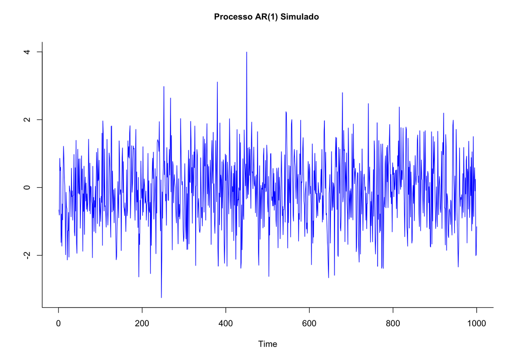

```r
#Inicio do Script
#Simulacao de um Processo AR (1)
Yt <- arima.sim(model=list(ar=0.20), n=1000)
#layout <- layout(matrix(c(1,1,2,3), nrow=2, ncol=2, byrow=T))
plot(Yt,
     lty=1, lwd=1,bty='l',
     main='',
     ylab='', col='blue')
mtext('Processo AR(1) Simulado ', side=3, line=2, font=2)
```

## 4.3 FAC, FACp e Teste de Ljung-Box

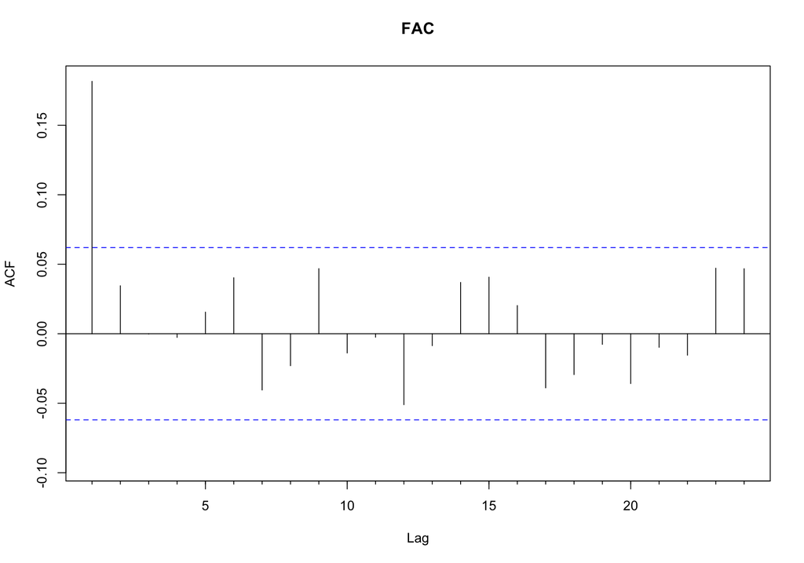

```r
Acf(Yt, lag.max = 24, main='FAC')
```

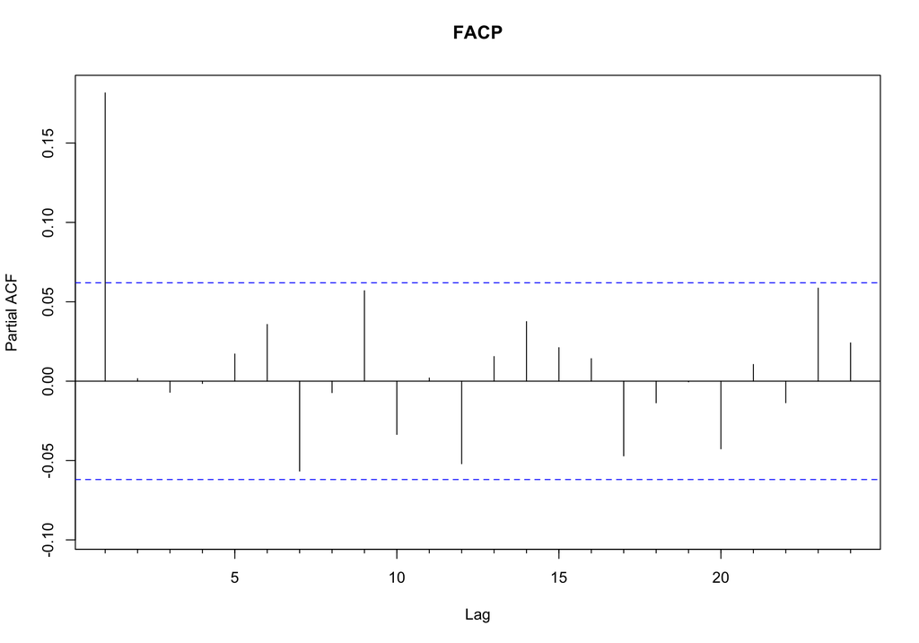

```r
Pacf(Yt, lag.max = 24, main='FACP')
```

```r
Box.test(Yt, lag=20, type = "Ljung")
```

```
#
#   Box-Ljung test
#
# data:  Yt
# X-squared = 50.783, df = 20, p-value = 0.0001709
```

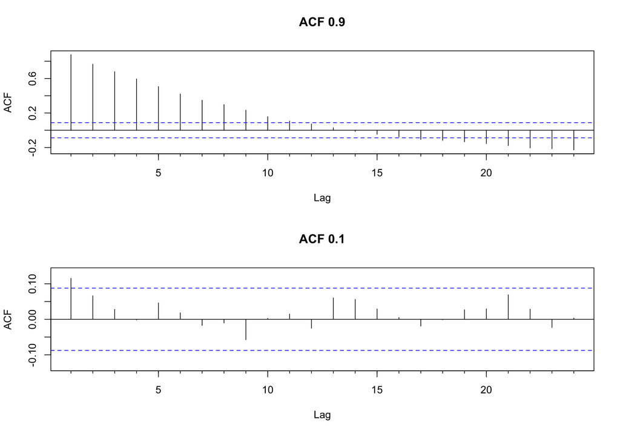

```r
Xt <- arima.sim(model=list(ar=0.9), n=500)
Zt <- arima.sim(model=list(ar=0.1), n=500)
par(mfrow=c(2,1))

# FAC e FACp
Acf(Xt, lag.max = 24, main='ACF 0.9')
Acf(Zt, lag.max = 24, main='ACF 0.1')
```

## 4.5 Simulacao de um Processo MA (1)

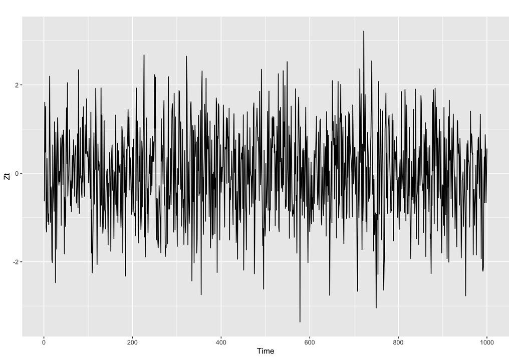

```r
Zt <- arima.sim(model=list(ma=0.1), n=1000)
autoplot(Zt)
```

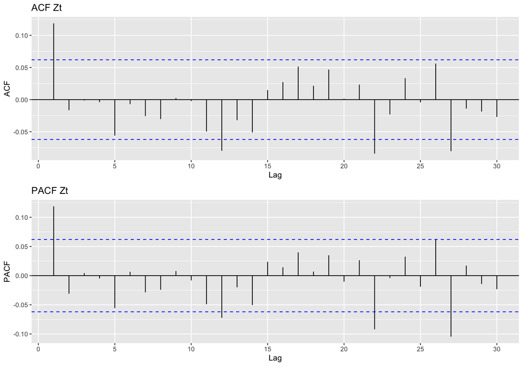

```r
# FAC e FACp
p1 <- ggAcf(Zt)+ggtitle('ACF Zt')
p2 <- ggPacf(Zt)+ggtitle('PACF Zt')
grid.arrange(p1, p2, ncol=1)
```

## 4.6 Visualizado as diferencas entre o AR(1) e o MA(1)

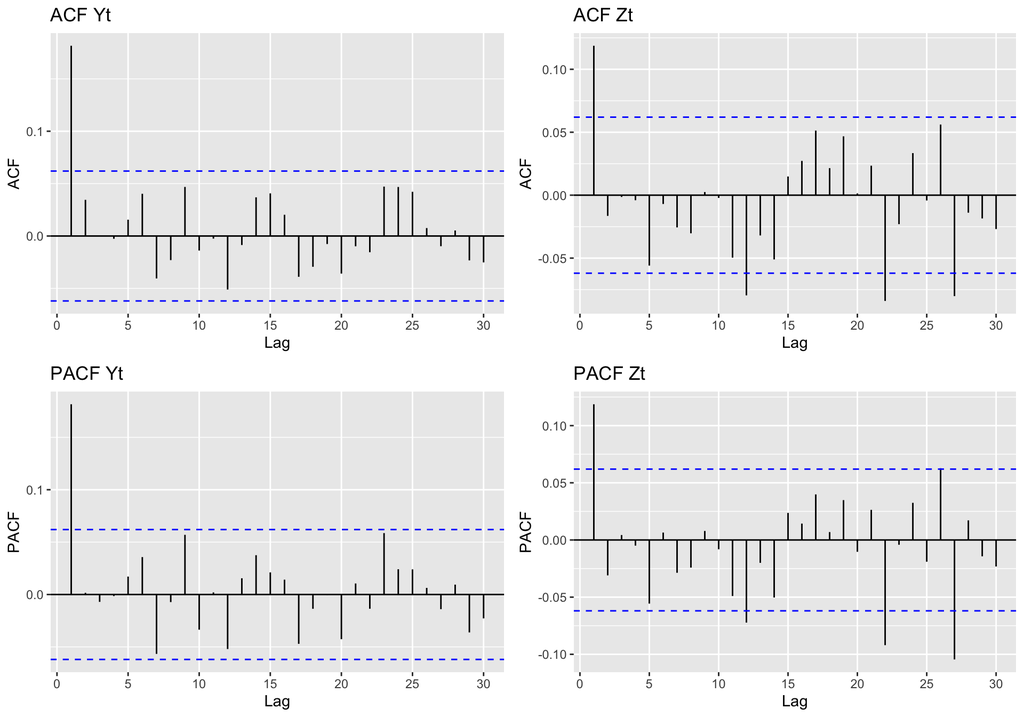

```r
p1 <- ggAcf(Zt)+ggtitle('ACF Zt')
p2 <- ggPacf(Zt)+ggtitle('PACF Zt')
p3 <- ggAcf(Yt)+ggtitle('ACF Yt')
p4 <- ggPacf(Yt)+ggtitle('PACF Yt')
grid.arrange(p3, p1, p4, p2, ncol=2)
```

## 4.7 Processos ARMA (1,1)

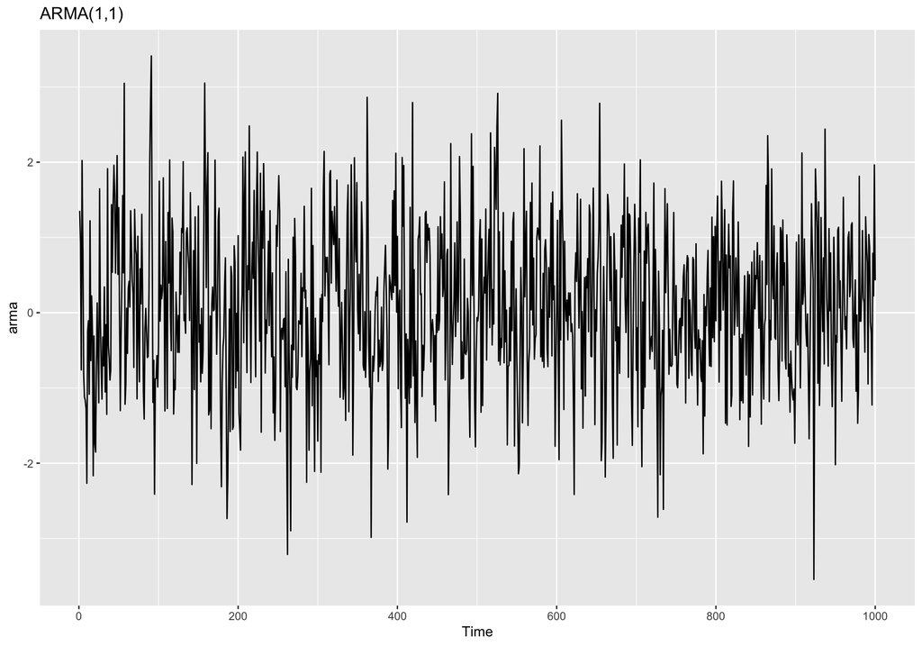

```r
arma <- arima.sim(list(order = c(1,0,1), ar = 0.1, ma=0.1), n = 1000)
autoplot(arma)+ggtitle('ARMA(1,1)')
```

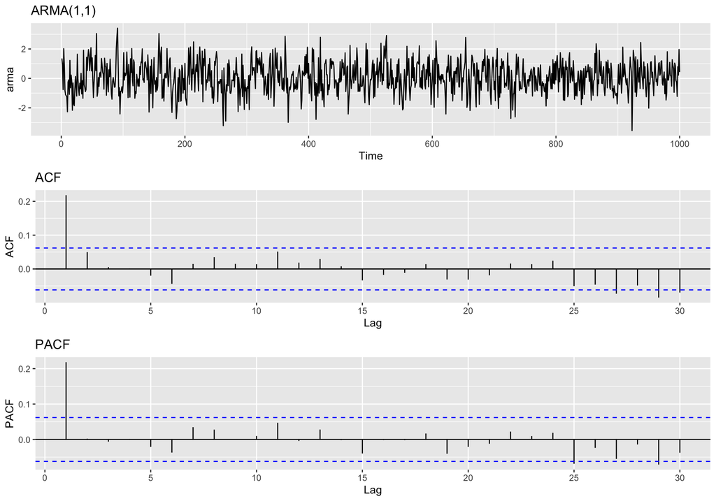

```r
g1 <- autoplot(arma)+ggtitle('ARMA(1,1)')
g2 <- ggAcf(arma)+ggtitle('ACF')
g3 <- ggPacf(arma)+ggtitle('PACF')
grid.arrange(g1, g2, g3, ncol=1)
```